# Introduction to Numerical Cosmology

Overview

- **Objective:** Introduce numerical methods in cosmology.
- **Agenda:**
  1. Numerical Cosmology
  2. Numerical Methods
  3. Python in Numerical Cosmology
  4. Hands-On Activity

# 1) Numerical Cosmology

## Why Do We Need Numerical Cosmology?

### 1.1) Complexity of Cosmological Equations

- Many problems in cosmology (and not only) are **nonlinear** and **coupled**.
- **Analytical solutions** are often infeasible or impossible.
- Example:
  - Many-body problem

Dynamic Range of Scales

- Cosmology spans from **subatomic particles** to the **entire universe**.
- Numerical methods allow (in principle) simulating **multiple scales simultaneously**.
- Time-dependent phenomena require **evolving solutions**.

**Discussion:** Think of cosmological problems that cannot be solved analytically and why.

[figure not shown]

## Why Now? The Role of Modern Computing

### 1.2) Advancements in Computational Power

#### **Are you curious to benchmark your PC?**

1. **Get the latest version of HPL**: [Download HPL](https://www.netlib.org/benchmark/hpl/)
   - On Linux, installation is straightforward:

     ```
     ./configure --prefix=$HOME && make && make install
     ```

   - The `xhpl` executable will be located in your `$HOME/bin` directory. It requires a specific parameter file.
2. **Create a benchmark parameter file**:  
   Use this website to generate one: [Advanced Clustering HPL.dat Tuning Tool](https://www.advancedclustering.com/act_kb/tune-hpl-dat-file/)
3. **Compare your results**:  
   Check your benchmark outcome against Cineca's historical data on [Top500](https://top500.org/site/47495/).

## Visualization

[figure not shown]

## Extra Care Needed in Numerical Solutions

### 1.3) Numerical Stability and Error Analysis

- **Numerical Stability:**
  - Importance of choosing appropriate algorithms to prevent instability.
  - Avoid pitfalls like rounding errors and divergence.
- **Error Types:**
  - **Truncation Errors:** Due to approximations in numerical methods.
  - **Round-off Errors:** Due to finite precision in computations.

```python
import sympy as sp
import numpy as np
import matplotlib.pyplot as plt

# Define the variable
x = sp.symbols('x')

# Define the function
f = sp.ln(1 + x)

# Degree of expansion (adjust as needed)
degree = 15

# Perform the Taylor expansion around x=0
taylor_expansion = sp.series(f, x, 0, degree + 1).removeO()

# Convert the symbolic expression to a numerical function for plotting
taylor_func = sp.lambdify(x, taylor_expansion, 'numpy')
original_func = sp.lambdify(x, f, 'numpy')

# Generate x values for the plot
x_vals = np.linspace(-0.9, 1.5, 500)  # Avoid x=-1 to prevent a singularity
# Correct the formatting issue by ensuring the LaTeX string is properly prepared
expansion_expr = sp.latex(taylor_expansion)
```

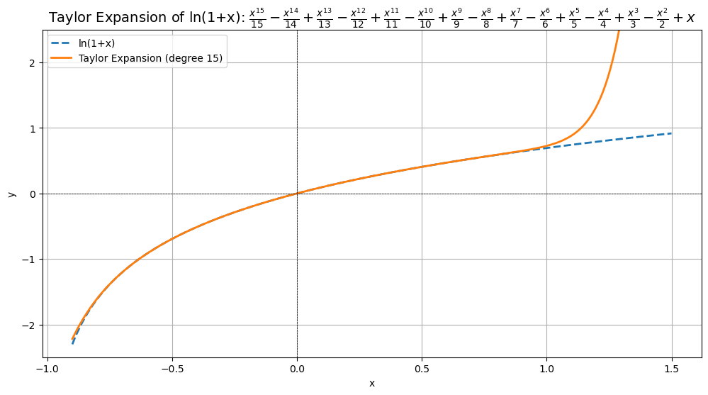

```python
from scipy.interpolate import pade

# Define the variable
x = sp.symbols('x')
# Define the function
f = sp.ln(1 + x)
# Fixed order of Taylor expansion
order = 15
# Extract Taylor series coefficients using SymPy and convert to numerical values
taylor_series = f.series(x, 0, order).removeO()
coefficients = [float(taylor_series.coeff(x, i)) for i in range(order)]
# Define degrees for the Padé approximant
m, n = 3, 3  # Numerator and denominator degrees
# Compute the Padé approximant using SciPy
p, q = pade(coefficients, m)
# Define the original function
original_func = sp.lambdify(x, f, 'numpy')
# Generate x values for plotting
x_vals = np.linspace(-0.9, 2.5, 500)  # Avoid x = -1 to prevent singularity
# Evaluate the Padé approximant and the original function
pade_values = p(x_vals) / q(x_vals)
original_values = original_func(x_vals)
```

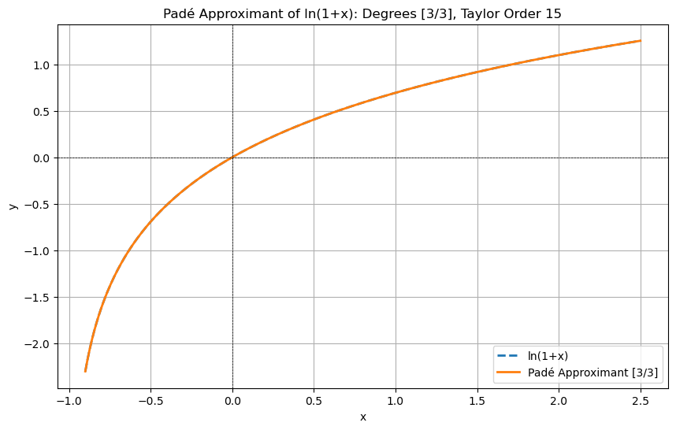

```python
import numpy as np
import matplotlib.pyplot as plt

# Set the random seed for reproducibility
np.random.seed(1234)
# Generate an array 'x' of 1,000,000 random numbers between 0 and 1
# Convert the numbers to 32-bit floating point format to simulate single precision
x = np.random.rand(1_000_000).astype(np.float32)
# Initialize an empty list to store the computed means
sums = []
# Repeat the process 3,000 times
for i in range(3_000):
    # Randomly shuffle the elements of 'x' in place
    # This changes the order of the numbers in 'x'
    np.random.shuffle(x)
    # Compute the sum of 'x' using single-precision arithmetic
    # The 'dtype' parameter ensures that the sum is computed using 32-bit floats
    sum_i = np.sum(x, dtype=np.float32) / x.size  # Divide by the number of elements to get the mean
    # Append the computed mean to the list 'sums'
    sums.append(sum_i)
# Plot a histogram of the computed means
plt.hist(sums, bins=30, edgecolor='black')
plt.xlabel('Mean Value')
plt.ylabel('Frequency')
plt.title('Distribution of Computed Means (Single Precision)')
plt.savefig("roundoff.png")
plt.show()
```

[figure not shown]

## Validation and Verification

- **Validation:**
  - Compare numerical results with known solutions.
- **Verification:**
  - Compare with independent implementations.

[figure not shown]

# 2) Numerical Methods in Cosmology

## Exact vs. Approximate Numerical Methods

- **Objective:** Understand different numerical approaches in cosmology.
- **Types:**
  - **Exact Numerical Solutions**
  - **Approximate Methods**

## Exact Numerical Solutions

### 2.1) Definition and Examples

- **Definition:**
  - Solutions limited only by computational precision.
- **Examples:**
  - **Boltzmann Codes:** e.g., CAMB, CLASS.
  - **N-body Simulations:** Simulate gravitational interactions of particles.

## Considerations for Exact Methods

- **Computational Resources:**
  - High demand on CPU/GPU time and memory.
- **Precision vs. Cost:**
  - Higher resolution increases accuracy but also computational cost.

**Discussion:** How does increasing resolution affect simulations?

[figure not shown]

```python
import numpy as np
import matplotlib.pyplot as plt
# Define the original function and its derivative
def f(x):
    return np.sin(x)
def f_prime(x):
    return np.cos(x)
# Set up the range and step size
x_exact = np.linspace(0, 2 * np.pi, 400)
y_exact = f(x_exact)
# Euler's method parameters
h = np.pi / 10  # Step size
x_approx = np.arange(0, 2 * np.pi + h, h)
y_approx = np.zeros(len(x_approx))
y_approx[0] = f(0)  # Initial condition
# Apply Euler's method
for i in range(1, len(x_approx)):
    y_approx[i] = y_approx[i - 1] + h * f_prime(x_approx[i - 1])
```

```python
# Plotting
plt.figure(figsize=(10, 6))
# Plot the exact function as a filled curve
plt.fill_between(x_exact, y_exact, color='lightblue', alpha=0.5, label='Exact Function $f(x) = \sin(x)$')
# Plot the approximate function
plt.plot(x_approx, y_approx, 'ro-', label='Approximate Function via Euler\'s Method')
# Plot tangent lines at each step
for i in range(len(x_approx) - 1):
    slope = f_prime(x_approx[i])
    x_tangent = np.linspace(x_approx[i], x_approx[i+1], 10)
    y_tangent = y_approx[i] + slope * (x_tangent - x_approx[i])
    plt.plot(x_tangent, y_tangent, 'r--', alpha=0.6)
# Labels and legend
plt.title('Numerical Integration Using Euler\'s Method')
plt.xlabel('$x$')
plt.ylabel('$y$')
plt.legend()
plt.grid(True)
```

[figure not shown]

```python
import numpy as np
import matplotlib.pyplot as plt
# Define the original function and its derivatives
def f(x):
    return np.sin(10*x)
def f_prime(x):
    return 10*np.cos(10*x)
def f_double_prime(x):
    return -100*np.sin(10*x)
```

```python
# Initial conditions
x0 = 0
xf = 2 * np.pi
y0 = f(x0)
# Parameters for adaptive timestep
k = 0.05            # Proportionality constant
epsilon = 1e-9      # Small number to prevent division by zero
h_min = 0.0         # Minimum timestep
h_max = (xf-x0)/100 # Maximum timestep
# Arrays to store the approximated solution
x_approx = [x0]
y_approx = [y0]
h_values = []
x = x0
y = y0
```

```python
# Adaptive Euler's method
while x < xf:
    # Compute second derivative
    f_dd = f_double_prime(x)
    # Compute timestep h
    h = k * np.sqrt(np.pi / (np.abs(f_dd) + epsilon))
    h = np.clip(h, h_min, h_max)
    # Ensure we don't overshoot the final value
    if x + h > xf:
        h = xf - x
    # Store timestep
    h_values.append(h)
    # Update x and y using Euler's method
    y += h * f_prime(x)
    x += h
    # Store the results
    x_approx.append(x)
    y_approx.append(y)
# Exact solution for comparison
x_exact = np.linspace(x0, xf, 400)
y_exact = f(x_exact)
```

```python
# Plotting
plt.figure(figsize=(12, 6))
# Plot the exact function as a filled curve
plt.fill_between(x_exact, y_exact, color='lightblue', alpha=0.5, label='Exact Function $f(x) = \sin(x)$')
# Plot the approximate function
plt.plot(x_approx, y_approx, 'ro-', label='Approximate Function with Adaptive Timestep')
# Plot tangent lines at each step
for i in range(len(x_approx) - 1):
    slope = f_prime(x_approx[i])
    x_tangent = np.linspace(x_approx[i], x_approx[i+1], 10)
    y_tangent = y_approx[i] + slope * (x_tangent - x_approx[i])
    plt.plot(x_tangent, y_tangent, 'r--', alpha=0.6)
# Labels and legend
plt.title('Numerical Integration with Adaptive Timestep')
plt.xlabel('$x$')
plt.ylabel('$y$')
plt.legend()
plt.grid(True)
```

[figure not shown]

## Approximate Methods

### 2.2) Definition and Examples

- **Definition:**
  - Use approximations to simplify computations.
- **Examples:**
  - **Emulators:** Machine learning to interpolate simulation results.
  - **Fitting Functions:** Empirical formulas derived from data.

## Advantages and Limitations

- **Advantages:**
  - Faster computations.
  - Useful for parameter studies and real-time analysis.
- **Limitations:**
  - Valid only within certain parameter ranges.
  - Less precise than exact methods.

# 3) Python in Numerical Cosmology

### 3.1) Advantages of Python

- **Ease of Use:**
  - Simple syntax and readable code.
- **Scientific Libraries:**
  - **NumPy:** Efficient array operations.
  - **SciPy:** Advanced algorithms and functions.
  - **Matplotlib:** Plotting and visualization.
- **Community Support:**
  - Active development and support.
  - Cosmology-specific packages (e.g., Astropy, Healpy).

### 3.2) Performance Considerations

- **Interpreted Language:**
  - Slower execution compared to compiled languages (C/C++).
- **Optimization Techniques:**
  - Use efficient libraries (e.g., NumPy, SciPy).
  - **Numba:** Just-In-Time (JIT) compilation.
  - **Cython:** Compile Python code to C for speed.
  - **Parallel Computing:** Utilize multi-threading and multi-processing.

## When Performance Matters

- **Computationally Intensive Tasks:**
  - Profile code to find bottlenecks.
  - Integrate Python with faster languages if necessary.

# 4) Hands-On Activity in Python

## Review of Matter Power Spectrum and Growth Function

### 4.1) Key Concepts

- **Matter Power Spectrum:**
  - Describes the distribution of matter density fluctuations as a function of scale.
- **Growth Function ( D(a) ):**
  - Quantifies the growth of density perturbations over time.
- **Key Equation:** $$ \ddot{\delta} + 2H\dot{\delta} - \frac{3}{2} H^2 \Omega_m \delta = 0 $$
  - ( $\dot{\delta}$ ): Time derivative of ( $\delta$ ).
  - ( H ): Hubble parameter.
  - ( $\Omega_m$ ): Matter density constribution.

## Solving the Growth Function Numerically

### 4.2) Setup and Implementation

- **Define Cosmological Parameters:**
  - Let's assume a Flat-$\Lambda$CDM unverse.
  - Is the cosmic time variable the best choice for writing the ODE equations?
  - Which validation and verification strategy we are going to use?
- **Initial Conditions:**
  - Which initial conditions are apropriate?
- **Numerical Solver:**
  - Use `solve_ivp` from SciPy.

## Coding Session

- **Implementation Steps:**
  1. Define the system of equations.
  2. Set initial conditions.
  3. Choose a range for the scale factor ( a ).
  4. Implement the numerical solver.
- **Live Coding:**
  - Write code step by step.
  - Encourage troubleshooting and debugging.

```python
import numpy as np
from scipy.integrate import solve_ivp
import matplotlib.pyplot as plt

# Define constants
H0 = 70.0  # Hubble parameter at present time in km/s/Mpc
Omega_m = 1.0
Omega_Lambda = 1.0 - Omega_m

# Define the E(a)
def E(a):
    return np.sqrt(Omega_m / a**3 + Omega_Lambda)
# Define the Hubble parameter H(a)
def H(a):
    return H0 * E(a)
# Define Oma(a)
def Om(a):
    return Omega_m / a**3 / E(a)**2
# Define the derivative of H wrt lna
def dlnH_dlna (a):
    return -3/2 / E(a) **2 * Omega_m / a**3

# Define the system of equations
def growth_function(lna, y):
    a = np.exp(lna) # Get the scale factor
    dydt = [y[1],
            -y[1] * (dlnH_dlna(a)+2) + 3/2 * Om(a) * y[0]]
    return dydt
```

```python
from astropy.cosmology import FlatLambdaCDM
cosmo = FlatLambdaCDM(H0=H0, Om0=Omega_m, Tcmb0=0)
z = 1
print(cosmo.Om(z)/Om(1/(1+z)), cosmo.H(z).value/H(1/(1+z)))
```

```
1.0000000000000004 1.0
```

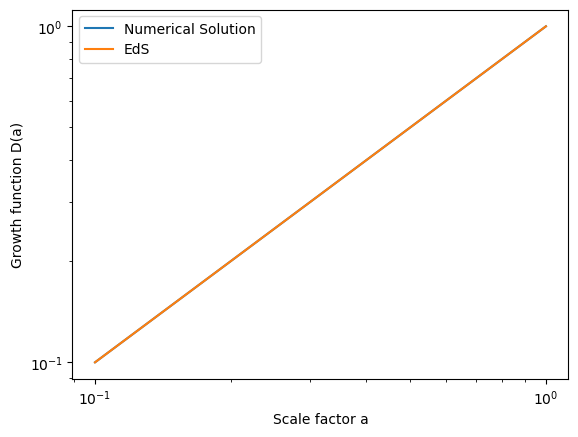

```python
# Initial conditions and time span
a0 = 1e-2
y0 = [a0, a0]  # Initial values for D and D'
t_span = [np.log(a0), np.log(1)]  # From a ~ 0 to a = 1

# Solve the ODE
sol = solve_ivp(growth_function, t_span, y0, method='RK45', dense_output=True, rtol=1e-6, atol=1e-9)

# Extract results
a = np.linspace(0.1, 1, 100)
D = sol.sol

# Plotting the results
plt.loglog(a, D(np.log(a))[0], label='Numerical Solution')
plt.loglog(a, a, label='EdS')
plt.xlabel('Scale factor a')
plt.ylabel('Growth function D(a)')
plt.legend()
plt.savefig("growth.png")
```

[figure not shown]